# MUSA Practicum Nighttime Economy

### Mapping Errors & Errors by Corridor Type

Finally, we map the errors by commercial corridor in the following figures. The absolute errors indicate that our model is less accurate predicting nighttime traffic for larger, more heavily-trafficked corridors. The Percent Errors map on the right, actually tells a slightly different story with the highest quintile of percent error along the smaller corridors throughout the city.

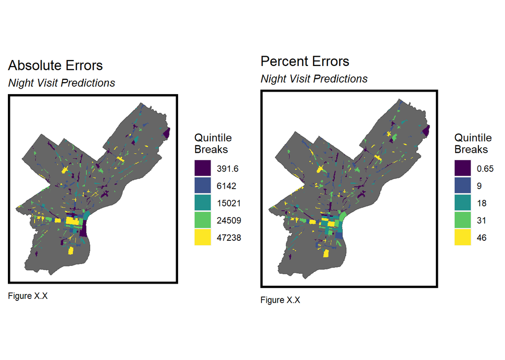

```r
cv_preds <- reg1.cv$pred

map_preds <- dat_pred_agg %>%
  rowid_to_column(var = "rowIndex") %>%
  left_join(cv_preds, by = "rowIndex") %>%
  group_by(corridor, corr_type) %>% #CONFIRM THIS APPROACH WITH MATT!
  summarise(Night_visits_sqmi = mean(Night_visits_sqmi),
            pred = mean(pred)) %>%
  dplyr::mutate(Visits.AbsError = abs(exp(pred) - Night_visits_sqmi),
         PercentError = (Visits.AbsError / Night_visits_sqmi)*100)

#Quintile maps
ErrorPlot1 <- ggplot() +
  geom_sf(data = phl_boundary, fill = "grey40") +
  geom_sf(data = map_preds, aes(fill = q5(Visits.AbsError)), color = "transparent") +
  scale_fill_manual(values = palette5,
                      labels=qBr(map_preds,"Visits.AbsError"),
                      name="Quintile\nBreaks") +
  labs(title="Absolute Errors",
       subtitle = "Night Visit Predictions",
       caption = "Figure X.X") +
  mapTheme()

ErrorPlot2 <- ggplot() +
  geom_sf(data = phl_boundary, fill = "grey40") +
  geom_sf(data = map_preds, aes(fill = q5(PercentError)), color = "transparent") +
  scale_fill_manual(values = palette5,
                      labels=qBr(map_preds, "PercentError"),
                      name="Quintile\nBreaks") +
  labs(title="Percent Errors",
       subtitle = "Night Visit Predictions",
       caption = "Figure X.X") +
  mapTheme()

grid.arrange(ErrorPlot1, ErrorPlot2, ncol=2)
```

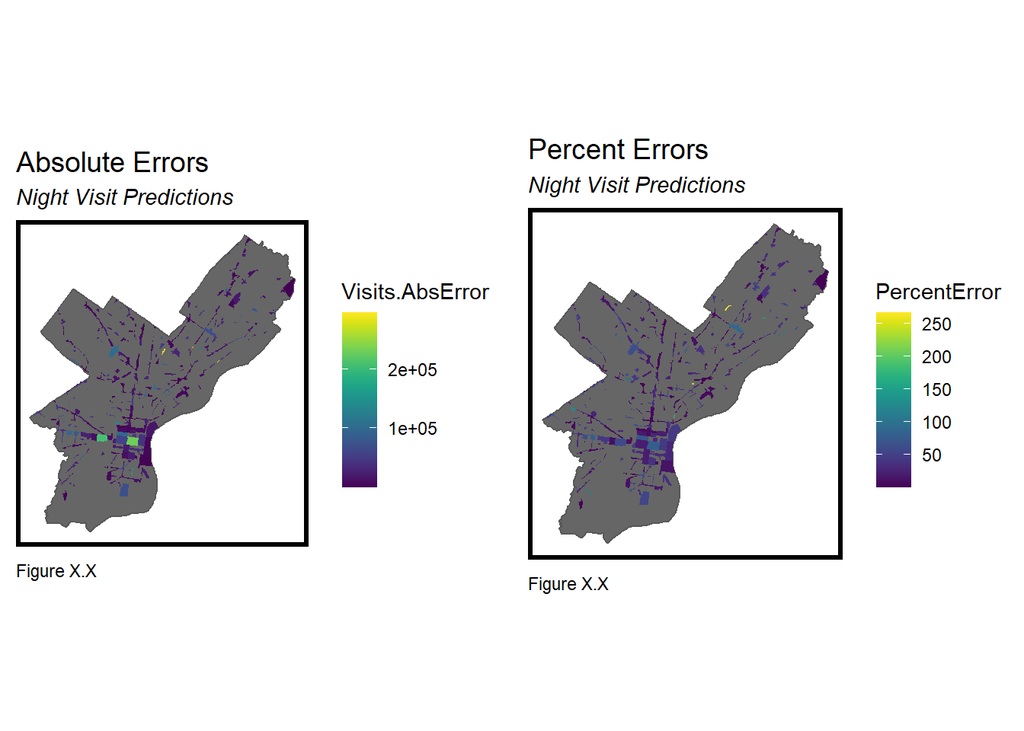

```r
#Non quintile errors
ErrorPlot3 <- ggplot() +
  geom_sf(data = phl_boundary, fill = "grey40") +
  geom_sf(data = map_preds, aes(fill = Visits.AbsError), color = "transparent") +
  scale_fill_viridis() +
  labs(title="Absolute Errors",
       subtitle = "Night Visit Predictions",
       caption = "Figure X.X") +
  mapTheme()

ErrorPlot4 <- ggplot() +
  geom_sf(data = phl_boundary, fill = "grey40") +
  geom_sf(data = map_preds, aes(fill = PercentError), color = "transparent") +
  scale_fill_viridis() +
  labs(title="Percent Errors",
       subtitle = "Night Visit Predictions",
       caption = "Figure X.X") +
  mapTheme()

grid.arrange(ErrorPlot3, ErrorPlot4, ncol=2)
```

```r
map_preds %>%
  st_drop_geometry() %>%
  group_by(corr_type) %>%
  summarize(Avg.Visits.AbsError = mean(Visits.AbsError),
            Avg.PercentError = mean(PercentError)) %>%
  kable(caption = "Errors by corridor type") %>%
  kable_styling()
```

[output not shown]

Errors by corridor type